# FigureYa52 GOplot

# Academic Citation

If you use this code in your work or research, we kindly request that you cite our publication:

Xiaofan Lu, et al. (2025). FigureYa: A Standardized Visualization Framework for Enhancing Biomedical Data Interpretation and Research Efficiency. iMetaMed. https://doi.org/10.1002/imm3.70005

## 需求描述

用GOplot展示clusterProfiler的富集分析结果，画出paper里的⭕️图

## Requirement description

Display the enrichment analysis results of clusterProfiler using GOplot and draw the data in the paper ⭕ ️ Image

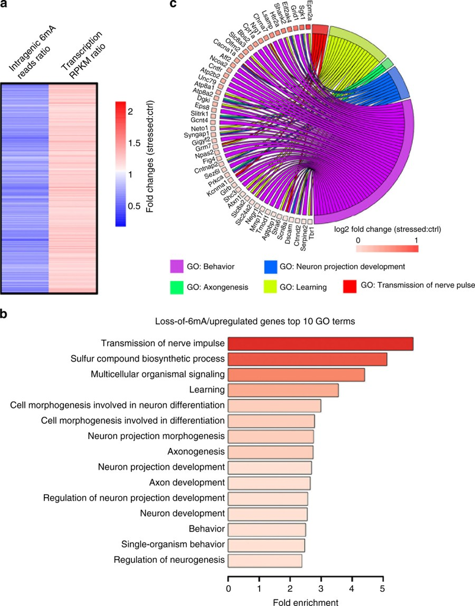

出自https://www.nature.com/articles/s41467-017-01195-y

fromhttps://www.nature.com/articles/s41467-017-01195-y

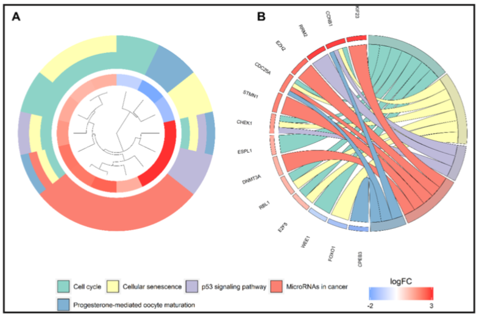

出自https://www.karger.com/Article/FullText/492519

fromhttps://www.karger.com/Article/FullText/492519

## 应用场景

适用于：既想用clusterProfiler做富集分析，又想用GOplot展示结果，但是不知道二者怎样衔接的小伙伴。

此处以GO为例，获得clusterProfiler的富集分析结果，生成GOplot所需的格式，用GOplot画⭕️图。

clusterProfiler除了擅长做GO富集分析以外，还可以用KEGG、Diseaes、Reactome、DAVID、MSigDB等注释库做富集分析。另外，enrichplot自带的gseaplot2函数可以生成GSEA结果的矢量图、多条pathway画到同一个图上，完美代替Java版本的GSEA，看这篇：https://mp.weixin.qq.com/s/AamfRz0BUENCi_1P0P-Ruw。

## Application scenarios

Suitable for: those who want to use clusterProfiler for enrichment analysis and GOplot to display results, but do not know how to connect the two.

Taking GO as an example, obtain the enrichment analysis results of clusterProfiler, generate the required format for GOplot, and use GOplot to draw ⭕ Picture.

In addition to being proficient in GO enrichment analysis, clusterProfiler can also use annotation libraries such as KEGG, Disseales, Reactor, DAVID, MSigDB, etc. for enrichment analysis. In addition, enrichplot’s built-in gseaplot2 function can generate vector graphs of GSEA results and draw multiple pathways onto the same graph, perfectly replacing the Java version of GSEA. See this article:< https://mp.weixin.qq.com/s/AamfRz0BUENCi_1P0P-Ruw>

## 环境设置

安装需要的包

## Environment settings

```r
source("install_dependencies.R")
```

[output not shown]

```
## ✅ AnnotationHub package loaded successfully!
```

```r
# 加载用于功能富集分析的包 | Load packages for functional enrichment analysis
library(clusterProfiler)
# 加载用于生物信息学注释资源的包 | Load package for bioinformatics annotation resources
library(AnnotationHub)
# 加载用于注释数据库接口的包 | Load package for annotation database interface
library(AnnotationDbi)
```

```r
# 加载用于基因本体可视化的包 | Load package for Gene Ontology visualization
library(GOplot)
# 加载用于数据可视化的包 | Load package for data visualization
library(ggplot2)
library(org.Mm.eg.db)
# 设置环境变量以显示英文报错信息 | Set environment variable to display English error messages
Sys.setenv(LANGUAGE = "en")
# 设置选项禁止将字符向量自动转换为因子 | Set option to prevent automatic conversion of character vectors to factors
options(stringsAsFactors = FALSE)
```

## 获取ENTREZ ID跟基因名的对应关系

如果你的基因ID已经是ENTREZ ID，并保存成`very_easy_input_**.csv`的格式，就可以跳过这步，直接进入“富集分析”

## Obtain the correspondence between ENTREZ ID and gene name

If your gene ID is already ENTREZ ID and saved in the format of ’very easy input * *. csv’, you can skip this step and directly enter ‘enrichment analysis’

### 人和模式生物ENTREZ ID的获取

此处以例文中的小鼠数据为例，其他18个物种只需更改`OrgDb = "org.Mm.eg.db"`参数

具体物种对应的R包名字看这页：http://bioconductor.org/packages/release/BiocViews.html#___OrgDb

如果你关心的物种不在这个列表里，请跳过这步，直接进入“非模式生物ENTREZ ID的获取”

### Obtaining ENTREZ IDs for humans and model organisms

Taking the mouse data in the example article as an example, the other 18 species only need to change the ‘OrgDb=’ org. Mm. eg. db ’parameter

Please refer to this page for the R package names corresponding to specific species:< http://bioconductor.org/packages/release/BiocViews.html#___OrgDb >

If the species you are concerned about is not in this list, please skip this step and go directly to “Obtaining ENTREZ ID for Non model Organisms”

```r
# 从CSV文件读取基因符号和表达量数据 | Read gene symbols and expression data from CSV file
gsym.fc <- read.csv("easy_input_Mm.csv", as.is = T)
# 查看数据维度（行数和列数） | Check the dimensions (rows and columns) of the data
dim(gsym.fc)
```

```
## [1] 201   2
```

```r
# 查看可用的ID类型（此行为注释，未执行） | View available ID types (commented out)
# keytypes(org.Mm.eg.db)

# 将基因符号转换为ENTREZ ID | Convert gene symbols to ENTREZ IDs
gsym.id <- bitr(gsym.fc$SYMBOL,         # 基因名列 | Gene symbol column
                fromType = "SYMBOL",     # 输入ID类型为基因符号 | Input ID type: gene symbol
                toType = "ENTREZID",     # 输出ID类型为ENTREZ ID | Output ID type: ENTREZ ID
                OrgDb = "org.Mm.eg.db")  # 小鼠注释数据库 | Mouse annotation database
# 查看转换结果前几行 | View first few rows of the conversion result
head(gsym.id)
```

```
##    SYMBOL ENTREZID
## 1    Atrn    11990
## 2 Cacna1e    12290
## 3 Cacna1g    12291
## 4   Capn2    12334
## 5   Cdh11    12552
## 6    Cdh4    12561
```

```r
# 合并基因名、ENTREZ ID和表达量变化值 | Merge gene symbols, ENTREZ IDs and fold change values
idvec <- gsym.id$ENTREZID  # 创建ENTREZ ID向量 | Create vector of ENTREZ IDs
names(idvec) <- gsym.id$SYMBOL  # 设置向量名称为基因符号 | Set vector names as gene symbols
gsym.fc$ENTREZID <- idvec[gsym.fc$SYMBOL]  # 将ENTREZ ID匹配到原始数据 | Map ENTREZ IDs to original data
# 查看合并后数据前几行 | View first few rows of merged data
head(gsym.fc)
```

```
##    SYMBOL    log2fc ENTREZID
## 1    Atrn -0.308724    11990
## 2 Cacna1e -0.352114    12290
## 3 Cacna1g -0.300020    12291
## 4   Capn2 -0.199424    12334
## 5   Cdh11 -0.206564    12552
## 6    Cdh4 -0.500161    12561
```

```r
# 将处理后的数据保存为CSV文件 | Save processed data to CSV file
write.csv(gsym.fc[,c(3,2)], "very_easy_input_Mm.csv",  # 选择第3列(ENTREZID)和第2列(表达量) | Select columns 3 (ENTREZID) and 2 (expression)
          quote = F,          # 不使用引号包裹字段 | Do not quote fields
          row.names = F)      # 不保存行名 | Do not save row names
```